# A summary of EngageESA tweets at ESA 2017 (#EngageESA)

E.J. Rollinson

## About this document

This document was produced by [Emily J. Rollinson](http://rollinsonecology.com) (ejrollinson on Twitter).

The code generating this document was originally developed by [Francois Michonneau](https://github.com/fmichonneau) (fmic_ on Twitter) for the 2015 Evolution meeting and can be found [here](https://github.com/fmichonneau/evol2015-tweets).

It has since been [adapted](https://github.com/jlehtoma/iccb2015-tweets/blob/gh-pages/index.Rmd) for ICCB-ECCB 2015 by Joona Lehtomaki (jlehtoma on Twitter).

Thanks also to Emily Sessa (ebsessa on Twitter) for reproducing this code for the 2015 Botany meeting, bringing it to my attention.

I originally adapted this code for the 2015 Ecological Society of America meeting (#ESA100) in Baltimore, MD, and have since reproduced it for [subsequent ESA and Botany meetings](https://erollinson.github.io/).

Tweets using the hashtag #EngageESA were aggregated from Twitter using the R package [twitteR](https://cran.r-project.org/web/packages/twitteR/index.html) and the Twitter API. The aggregated tweets are [available on Figshare](https://figshare.com/articles/Tweets_using_ESA2017_hashtag/5306302).

This document was generated using RMarkdown, and the source is [available on GitHub](https://github.com/erollinson/erollinson.github.io).

This document (and associated code) is released under a CC0 licence.

## Basic summary

Of the 142 tweets tagged #EngageESA as of 12:30 PM EST 8/13/2017:

| Description | n |
| --- | --- |
| Total of original tweets (no retweets): | 79 |
| Number of users who tweeted: | 48 |

## The 5 most favorited tweets

> Universities needs to create reward structures for scientists who are effective in public engagement. - @JaneLubchenco #EngageESA #ESA2017

> — melissakenney | [2017-08-08](https://twitter.com/melissakenney/status/894762577003069440) | 46 retweets, 129 favorites.

> Super #EngageESA speakers ready to answer questions. #ESA2017 @JaneLubchenco @EngageClimate @JessicaHellmann https://t.co/I5vWxT4W6l

> — A_Hettinger | [2017-08-07](https://twitter.com/A_Hettinger/status/894702320566521856) | 3 retweets, 17 favorites.

> It’s a really exciting to time to be an ecologist and help chart our common future-@JaneLubchenco #ESA2017 https://t.co/dxa2m4H2dS

> — melissakenney | [2017-08-08](https://twitter.com/melissakenney/status/894757963314769920) | 6 retweets, 12 favorites.

> Become bilingual - learn the language of science and non-scientists for effective public engagement -@JaneLubchenco #ESA2017 #EngageESA

> — melissakenney | [2017-08-08](https://twitter.com/melissakenney/status/894760061993603072) | 3 retweets, 11 favorites.

> .@JaneLubchenco Part of pushback from institutions re: making engagement “count” relates to how to evaluate quality. #EngageESA #ESA2017

> — A_Hettinger | [2017-08-07](https://twitter.com/A_Hettinger/status/894706718944264192) | 4 retweets, 10 favorites.

## The 5 most retweeted tweets

> Universities needs to create reward structures for scientists who are effective in public engagement. - @JaneLubchenco #EngageESA #ESA2017

> — melissakenney | [2017-08-08](https://twitter.com/melissakenney/status/894762577003069440) | 46 retweets, 129 favorites.

> Attending #ESA2017? Find your #SciComm niche at our #EngageESA workshop! https://t.co/z8aA4De1Vk https://t.co/ucRUDRUgc7

> — _SciComm | [2017-08-07](https://twitter.com/_SciComm/status/894564023412432896) | 7 retweets, 2 favorites.

> It’s a really exciting to time to be an ecologist and help chart our common future-@JaneLubchenco #ESA2017 https://t.co/dxa2m4H2dS

> — melissakenney | [2017-08-08](https://twitter.com/melissakenney/status/894757963314769920) | 6 retweets, 12 favorites.

> This thread for #EngageESA session #ESA2017 https://t.co/t5E6yjkf3m

> — A_Hettinger | [2017-08-07](https://twitter.com/A_Hettinger/status/894703057073602560) | 6 retweets, 10 favorites.

> Today at 3:30 your #SciEngage w @sandygrad me @MatthewHurteau @JessicaHellmann @duffy_ma #ESA2017 #EngageESA https://t.co/3dr2NASRU8

> — EngageClimate | [2017-08-07](https://twitter.com/EngageClimate/status/894600976639721472) | 5 retweets, 4 favorites.

## Top tweeters

All generated tweets (including retweets)

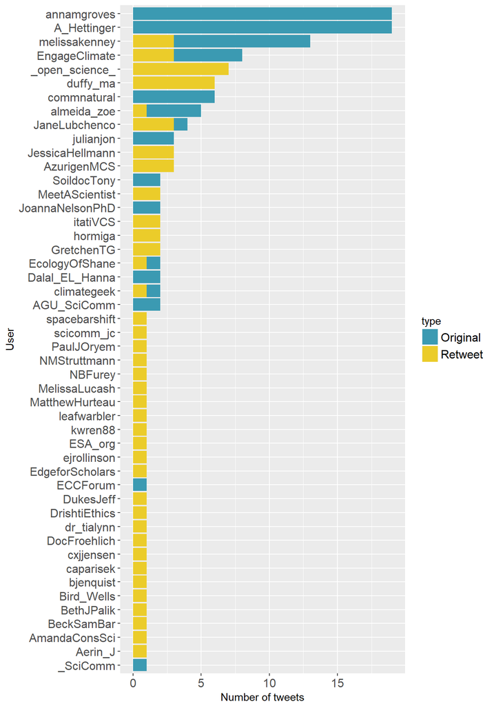

Only for original tweets (retweets excluded)

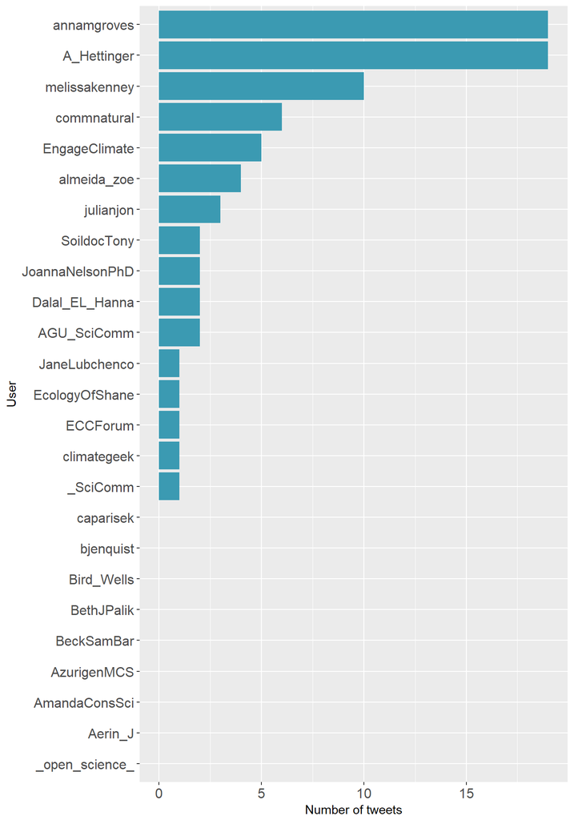

## Most favorited/retweeted users

The figures below only include users who tweeted 5+ times, and don’t include retweets.

### Number of favorites received by users

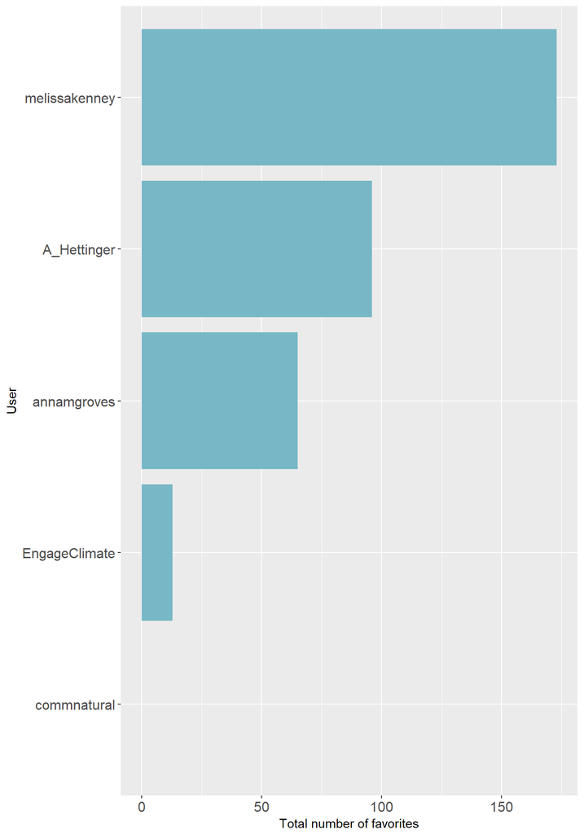

### Number of retweets received by users

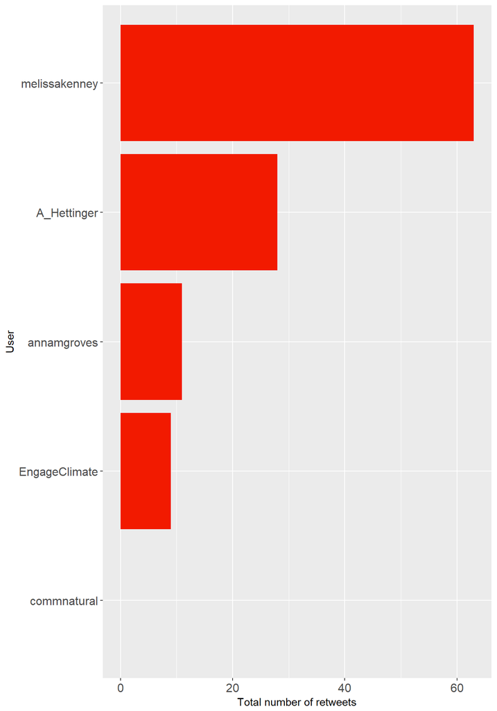

### Mean numbers of favorites received

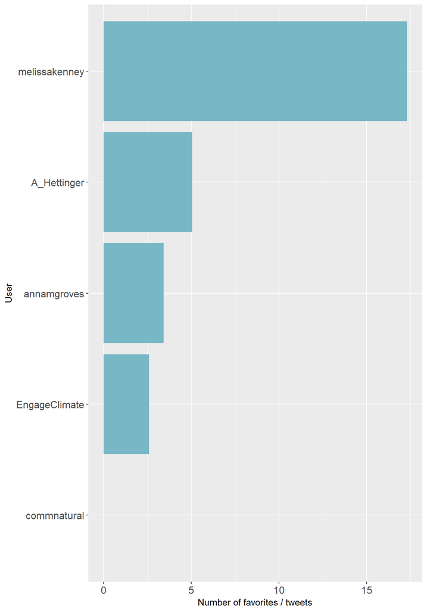

### Mean numbers of retweets received

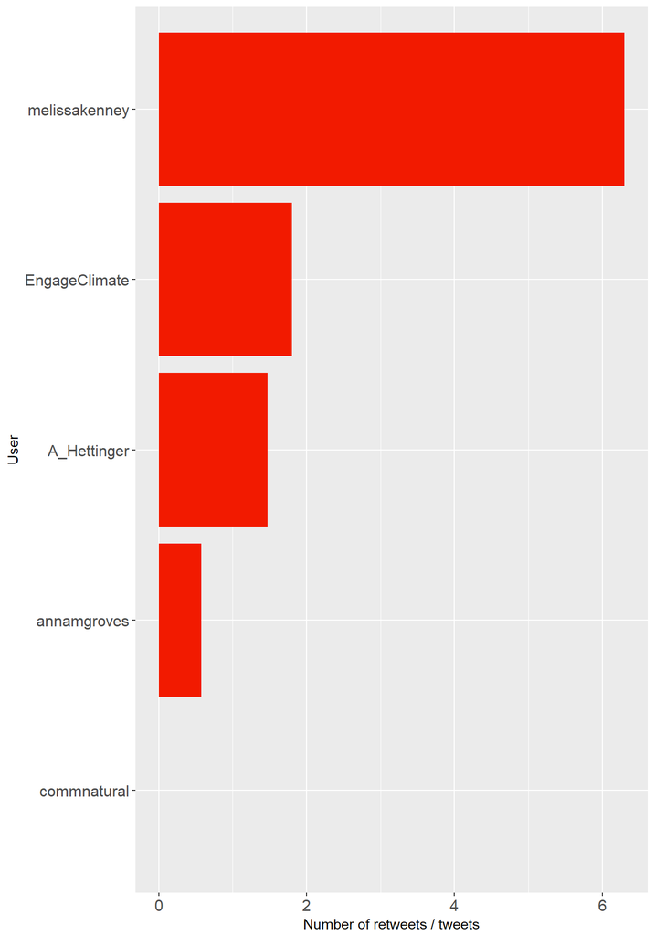

## Word cloud

The top 100 words among the original tweets (excludes RTs, hashtags, mentions, URLs, and “the’,”&“, etc.).

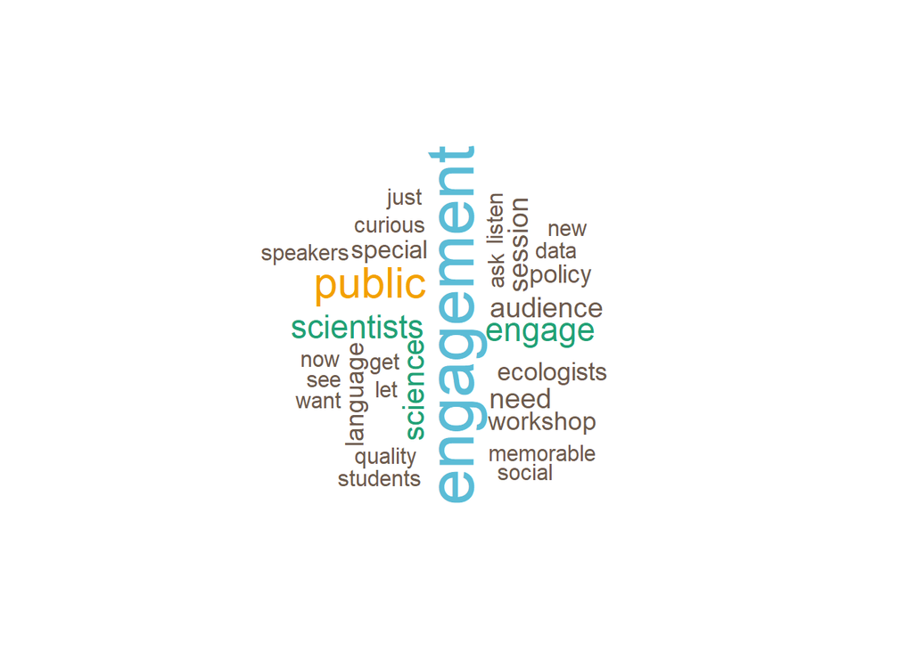

To the extent possible under law, [Emily J. Rollinson](https://github.com/erollinson/erollinson.github.io) has waived all copyright and related or neighboring rights to Summary of EngageESA tweets 2017. This work is published from: United States.